# statistics

*solution_03_central_limit_theorem/02_normal/08_x_from_rightarea_v1*

[video (using z-table)](https://vimeo.com/531935144)

[video (using app)](https://vimeo.com/531935582): the [app](http://18.191.167.248:3838/nprob/)

First, draw a sketch. We can label the $X$ axis by adding integer multiples of 0.15 to 0.61. We know to shade the right because high values of $X$ satisfy the condition $X>x$ (regardless of the exact value of $x$). We don’t know exactly where to place the boundary, but we know the right area is 0.94.

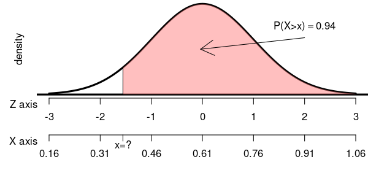

We know how to find the left area.
$$\begin{aligned}
P(X<x) &= 1-P(X>x) \\
&= 1-0.94 \\
&= 0.06
\end{aligned}$$

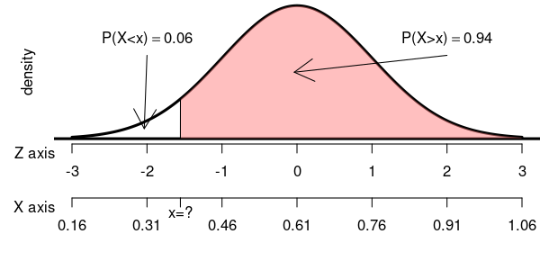

As an intermediate step, we find $z$ such that $P(Z<z)=0.06$.

By using the $z$ table we can determine $z$.

[output not shown]

Either -1.56 or -1.55 is a good estimation of $z$, and either value will lead you to an acceptable answer. Using other tools, a more accurate value can be found. I will show the work with a more accurate value.
$$z=-1.5548$$

We now convert the $z$ score into a $x$ score.
$$\begin{aligned}
x &= \mu+z\sigma \\
&= 0.61+(-1.5548)(0.15) \\
&= 0.3768
\end{aligned}$$

We can also visualize this with a spinner.

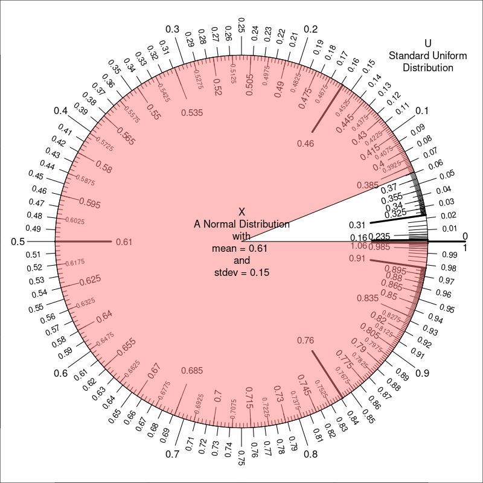

The tolerance for an acceptable answer was $\pm 0.01$ from 0.376784. So, anything between 0.366784 and 0.386784 was accepted.

ANSWERS: 0.376784  
TOLERANCES: 0.01